# 82 | 开源实战三（中）：剖析Google Guava中用到的几种设计模式

## Wrapper 模式在 Guava 中的应用

在 Google Guava 的 collection 包路径下，有一组以 Forwarding 开头命名的类。我截了这些类中的一部分贴到了下面，你可以看下。

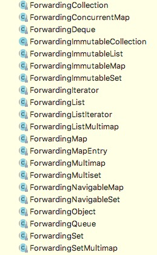

这组 Forwarding 类很多，但实现方式都很相似。我摘抄了其中的 ForwardingCollection 中的部分代码到这里，你可以下先看下代码，然后思考下这组 Forwarding 类是干什么用的。

@GwtCompatible

public abstract class ForwardingCollection<E> extends ForwardingObject implements Collection<E> {

protected ForwardingCollection() {

}

protected abstract Collection<E> delegate();

public Iterator<E> iterator() {

return this.delegate().iterator();

}

public int size() {

return this.delegate().size();

}

@CanIgnoreReturnValue

public boolean removeAll(Collection<?> collection) {

return this.delegate().removeAll(collection);

}

public boolean isEmpty() {

return this.delegate().isEmpty();

}

public boolean contains(Object object) {

return this.delegate().contains(object);

}

@CanIgnoreReturnValue

public boolean add(E element) {

return this.delegate().add(element);

}

@CanIgnoreReturnValue

public boolean remove(Object object) {

return this.delegate().remove(object);

}

public boolean containsAll(Collection<?> collection) {

return this.delegate().containsAll(collection);

}

@CanIgnoreReturnValue

public boolean addAll(Collection<? extends E> collection) {

return this.delegate().addAll(collection);

}

@CanIgnoreReturnValue

public boolean retainAll(Collection<?> collection) {

return this.delegate().retainAll(collection);

}

public void clear() {

this.delegate().clear();

}

public Object[] toArray() {

return this.delegate().toArray();

}

//...省略部分代码...

}

光看 ForwardingCollection 的代码实现，你可能想不到它的作用。我再给点提示，举一个它的用法示例，如下所示：

public class AddLoggingCollection<E> extends ForwardingCollection<E> {

private static final Logger logger = LoggerFactory.getLogger(AddLoggingCollection.class);

private Collection<E> originalCollection;

public AddLoggingCollection(Collection<E> originalCollection) {

this.originalCollection = originalCollection;

}

@Override

protected Collection delegate() {

return this.originalCollection;

}

@Override

public boolean add(E element) {

logger.info("Add element: " + element);

return this.delegate().add(element);

}

@Override

public boolean addAll(Collection<? extends E> collection) {

logger.info("Size of elements to add: " + collection.size());

return this.delegate().addAll(collection);

}

}

结合源码和示例，我想你应该知道这组 Forwarding 类的作用了吧？

在上面的代码中，AddLoggingCollection 是基于代理模式实现的一个代理类，它在原始 Collection 类的基础之上，针对“add”相关的操作，添加了记录日志的功能。

我们前面讲到，代理模式、装饰器、适配器模式可以统称为 Wrapper 模式，通过 Wrapper 类二次封装原始类。它们的代码实现也很相似，都可以通过组合的方式，将 Wrapper 类的函数实现委托给原始类的函数来实现。

public interface Interf {

void f1();

void f2();

}

public class OriginalClass implements Interf {

@Override

public void f1() { //... }

@Override

public void f2() { //... }

}

public class WrapperClass implements Interf {

private OriginalClass oc;

public WrapperClass(OriginalClass oc) {

this.oc = oc;

}

@Override

public void f1() {

//...附加功能...

this.oc.f1();

//...附加功能...

}

@Override

public void f2() {

this.oc.f2();

}

}

实际上，这个 ForwardingCollection 类是一个“默认 Wrapper 类”或者叫“缺省 Wrapper 类”。这类似于在装饰器模式那一节课中，讲到的 FilterInputStream 缺省装饰器类。你可以再重新看下第 50 讲装饰器模式的相关内容。

如果我们不使用这个 ForwardinCollection 类，而是让 AddLoggingCollection 代理类直接实现 Collection 接口，那 Collection 接口中的所有方法，都要在 AddLoggingCollection 类中实现一遍，而真正需要添加日志功能的只有 add() 和 addAll() 两个函数，其他函数的实现，都只是类似 Wrapper 类中 f2() 函数的实现那样，简单地委托给原始 collection 类对象的对应函数。

为了简化 Wrapper 模式的代码实现，Guava 提供一系列缺省的 Forwarding 类。用户在实现自己的 Wrapper 类的时候，基于缺省的 Forwarding 类来扩展，就可以只实现自己关心的方法，其他不关心的方法使用缺省 Forwarding 类的实现，就像 AddLoggingCollection 类的实现那样。

## Immutable 模式在 Guava 中的应用

Immutable 模式，中文叫作不变模式，它并不属于经典的 23 种设计模式，但作为一种较常用的设计思路，可以总结为一种设计模式来学习。之前在理论部分，我们只稍微提到过 Immutable 模式，但没有独立的拿出来详细讲解，我们这里借 Google Guava 再补充讲解一下。

一个对象的状态在对象创建之后就不再改变，这就是所谓的不变模式。其中涉及的类就是不变类（Immutable Class），对象就是不变对象（Immutable Object）。在 Java 中，最常用的不变类就是 String 类，String 对象一旦创建之后就无法改变。

不变模式可以分为两类，一类是普通不变模式，另一类是深度不变模式（Deeply Immutable Pattern）。普通的不变模式指的是，对象中包含的引用对象是可以改变的。如果不特别说明，通常我们所说的不变模式，指的就是普通的不变模式。深度不变模式指的是，对象包含的引用对象也不可变。它们两个之间的关系，有点类似之前讲过的浅拷贝和深拷贝之间的关系。我举了一个例子来进一步解释一下，代码如下所示：

// 普通不变模式

public class User {

private String name;

private int age;

private Address addr;

public User(String name, int age, Address addr) {

this.name = name;

this.age = age;

this.addr = addr;

}

// 只有getter方法，无setter方法...

}

public class Address {

private String province;

private String city;

public Address(String province, String city) {

this.province = province;

this.city= city;

}

// 有getter方法，也有setter方法...

}

// 深度不变模式

public class User {

private String name;

private int age;

private Address addr;

public User(String name, int age, Address addr) {

this.name = name;

this.age = age;

this.addr = addr;

}

// 只有getter方法，无setter方法...

}

public class Address {

private String province;

private String city;

public Address(String province, String city) {

this.province = province;

this.city= city;

}

// 只有getter方法，无setter方法..

}

在某个业务场景下，如果一个对象符合创建之后就不会被修改这个特性，那我们就可以把它设计成不变类。显式地强制它不可变，这样能避免意外被修改。那如何将一个不变类呢？方法很简单，只要这个类满足：所有的成员变量都通过构造函数一次性设置好，不暴露任何 set 等修改成员变量的方法。除此之外，因为数据不变，所以不存在并发读写问题，因此不变模式常用在多线程环境下，来避免线程加锁。所以，不变模式也常被归类为多线程设计模式。

接下来，我们来看一种特殊的不变类，那就是不变集合。Google Guava 针对集合类（Collection、List、Set、Map…）提供了对应的不变集合类（ImmutableCollection、ImmutableList、ImmutableSet、ImmutableMap…）。刚刚我们讲过，不变模式分为两种，普通不变模式和深度不变模式。Google Guava 提供的不变集合类属于前者，也就是说，集合中的对象不会增删，但是对象的成员变量（或叫属性值）是可以改变的。

实际上，Java JDK 也提供了不变集合类（UnmodifiableCollection、UnmodifiableList、UnmodifiableSet、UnmodifiableMap…）。那它跟 Google Guava 提供的不变集合类的区别在哪里呢？我举个例子你就明白了，代码如下所示：

public class ImmutableDemo {

public static void main(String[] args) {

List<String> originalList = new ArrayList<>();

originalList.add("a");

originalList.add("b");

originalList.add("c");

List<String> jdkUnmodifiableList = Collections.unmodifiableList(originalList);

List<String> guavaImmutableList = ImmutableList.copyOf(originalList);

//jdkUnmodifiableList.add("d"); // 抛出UnsupportedOperationException

// guavaImmutableList.add("d"); // 抛出UnsupportedOperationException

originalList.add("d");

print(originalList); // a b c d

print(jdkUnmodifiableList); // a b c d

print(guavaImmutableList); // a b c

}

private static void print(List<String> list) {

for (String s : list) {

System.out.print(s + " ");

}

System.out.println();

}

}

## 重点回顾

好了，今天的内容到此就讲完了。我们一块来总结回顾一下，你需要重点掌握的内容。

今天我们学习了 Google Guava 中都用到的几个设计模式：Builder 模式、Wrapper 模式、Immutable 模式。还是那句话，内容本身不重要，你也不用死记硬背 Google Guava 的某某类用到了某某设计模式。实际上，我想通过这些源码的剖析，传达给你下面这些东西。

我们在阅读源码的时候，要问问自己，为什么它要这么设计？不这么设计行吗？还有更好的设计吗？实际上，很多人缺少这种“质疑”精神，特别是面对权威（经典书籍、著名源码、权威人士）的时候。

我觉得我本人是最不缺质疑精神的一个人，我喜欢挑战权威，喜欢以理服人。就好比在今天的讲解中，我把 ForwardingCollection 等类理解为缺省 Wrapper 类，可以用在装饰器、代理、适配器三种 Wrapper 模式中，简化代码编写。如果你去看 Google Guava 在 GitHub 上的 Wiki，你会发现，它对 ForwardingCollection 类的理解跟我是不一样的。它把 ForwardingCollection 类单纯地理解为缺省的装饰器类，只用在装饰器模式中。我个人觉得我的理解更加好些，不知道你怎么认为呢？

除此之外，在专栏的最开始，我也讲到，学习设计模式能让你更好的阅读源码、理解源码。如果我们没有之前的理论学习，那对于很多源码的阅读，可能都只停留在走马观花的层面上，根本学习不到它的精髓。这就好比今天讲到的 CacheBuilder。我想大部分人都知道它是利用了 Builder 模式，但如果对 Builder 模式没有深入的了解，很少人能讲清楚为什么要用 Builder 模式，不用构造函数加 set 方法的方式来实现。

## 课堂讨论

从最后一段代码中，我们可以发现，JDK 不变集合和 Google Guava 不变集合都不可增删数据。但是，当原始集合增加数据之后，JDK 不变集合的数据随之增加，而 Google Guava 的不变集合的数据并没有增加。这是两者最大的区别。那这两者底层分别是如何实现不变的呢？

欢迎留言和我分享你的想法，如果有收获，也欢迎你把这篇文章分享给你的朋友。

[figure not shown]

## 精选留言(14)

[figure not shown]

- 成楠Peter

  2020-05-11

  JDK是浅拷贝，Guava使用的是深拷贝。一个复制引用，一个复制值。

  **

  ** 9

[figure not shown]

- hhhh

  2020-05-11

  猜测jdk中的不变集合保存了原始集合的引用，而guava应该是复制了原始集合的值。

  **

  ** 2

- 不能忍的地精

  2020-05-11

  Guava里面的引用已经是一个新的集合,Jdk里面的引用还是原来的集合

  **

  **

- Jxin

  2020-05-11

  1.两者都是生成一个新的集合对象。  
  2.前者相当于对原集合采用装饰者模式。通过复合方式限制掉原集合的写操作。实现，封装后的集合，在后续使用中不可变的特性。具有灵活性。  
  3.后者相当于新建一个不可变集合。通过原集合的元素，生成一个不可变集合。语义更加明确。  
  4.前者通过按需操作，具备灵活性。但在集合接口加缺省方法时，可能会有bug。毕竟它是以复合实现功能的。后者语义更明确，不具备前者的灵活性。但在集合接口加缺省方法时，一般不会有bug。因为它是操作自身数据结构实现的功能，与原集合无关联。

  展开**

  **

  **
- ，

  2020-05-11

  课后题:  
  jdk的不变集合引用了原始的集合类,所以在原始集合类发生改变的时候他也会改变,他的不可变只是客户端不可变;  
  guava的不变集合,是在重新创建了一个原始集合对象的副本,所以改变原始类并不能改变他的数据

  展开**

  **

  **

[figure not shown]

- 守拙

  2020-05-11

  通过阅读JDK源码, 发现UnmodifiableList内部使用原始List的浅拷贝, 所以当原始list增/删时会影响UnmodifiableList. 额外说一句, UnmodifiableList实现并Override了List接口的add(), remove()等方法, 通过抛出UnsupportedOperationException来抑制add/remove等改变数据源的操作.  
  Guava包下的ImmutableList.copyOf(Collection<? extends E> elements)内部调用了construct(elements.toArray())方法, 内部维护了源List的数组copy, 属于深拷贝范畴. 执行construct(elements.toArray())后, ImmutableList内部维护数组作为数据源, 与源List完全隔离, 所以源List的add/remove等操作不会影响到ImmutableList.  
  源码参考:  
  java.util.collections 1337行开始;(内部类UnmodifiableList)  
  com.google.common.collect.ImmutableList 238行开始.(copyOf方法)

  展开**

  **

  **

- 小晏子

  2020-05-11

  JDK中的unmodifiableList的构造函数是对原始集合的浅拷贝，而Guava.ImmutableList.copyOf是对原始集合的深拷贝。从source code可以看出来：  
  UnmodifiableList  
  UnmodifiableList(List<? extends E> list) {  
  super(list);  
  this.list = list;  
  }  
  Guava.ImmutableList.copyOf  
  public static <E> ImmutableList<E> copyOf(Collection<? extends E> elements) {  
  if (elements instanceof ImmutableCollection) {  
  @SuppressWarnings("unchecked") // all supported methods are covariant  
  ImmutableList<E> list = ((ImmutableCollection<E>) elements).asList();  
  return list.isPartialView() ? ImmutableList.<E>asImmutableList(list.toArray()) : list;  
  }  
  return construct(elements.toArray());  
  }  
  /** Views the array as an immutable list. Checks for nulls; does not copy. */  
  private static <E> ImmutableList<E> construct(Object... elements) {  
  return asImmutableList(checkElementsNotNull(elements));  
  }  
  /**  
  * Views the array as an immutable list. Does not check for nulls; does not copy.  
  *  
  * <p>The array must be internally created.  
  */  
  static <E> ImmutableList<E> asImmutableList(Object[] elements) {  
  return asImmutableList(elements, elements.length);  
  }  
  /**  
  * Views the array as an immutable list. Copies if the specified range does not cover the complete  
  * array. Does not check for nulls.  
  */  
  static <E> ImmutableList<E> asImmutableList(Object[] elements, int length) {  
  switch (length) {  
  case 0:  
  return of();  
  case 1:  
  return of((E) elements[0]);  
  default:  
  if (length < elements.length) {  
  elements = Arrays.copyOf(elements, length);  
  }  
  return new RegularImmutableList<E>(elements);  
  }  
  }

  展开**

  **

  **

[figure not shown]

- 汝林外史

  2020-05-11

  我觉得 ForwardingCollection 类就应该理解为缺省的装饰器类，前面的文章就说过代理模式、装饰器模式、适配器模式代码的写法几乎一样，差别就是各自的使用场景，我觉得ForwardingCollection这些类的使用场景就是作为装饰类来用的，不会应用到代理和适配器的场景，王老师貌似又掉入了以代码写法判断设计模式的自己说的陷阱中。

  展开**

  **

  **

[figure not shown]

- Snway

  2020-05-11

  Jdk直接引用原来的集合，guava是拷贝了原来的集合

  展开**

  **

  **

- test

  2020-05-11

  jdk是浅拷贝，guava是深拷贝，在修改的时候报错

  展开**

  **

  **

[figure not shown]

- whistleman

  2020-05-11

  要多思考背后为什么要用这种设计模式，才能对使用的设计模式有更深刻的理解。打卡！

  **

  **

[figure not shown]

- leezer

  2020-05-11

  我觉得我更赞同wrapper类的理解，因为装饰器的主要功能是在原始的类上做功能增强，而代理模式更多关注对非业务功能的关注。通过组合的方式我们能实现更多的Wrapper模式。这时候就不只是算装饰器的设计模式了  
  。

  展开**

  **

  **

[figure not shown]

- Jason

  2020-05-11

  思考题：我猜是深拷贝和浅拷贝的区别

  展开**

  **

  **

[figure not shown]

- 何用

  2020-05-11

  我是个特别能关注到细节的人。Memcached 是个开源库，不知道为何好多人都喜欢把它叫做 Memcache，本文也不例外。

  展开**

  **

  **